# BUAN 5210 01: Data Visualization

Group 6** Oksana Andruzova, Sugandha Baruah, Kalpana Bhandari, Tanya Bhardwaj, Quynh Nguyen, Vani Rishi

December 9th, 2022

[figure not shown]

# **Brazilian E-Commerce**

**Objective:**

At Olist, our mission is to expand the reach of small business owners beyond their traditional, brick-and-mortar customer base. Through our Saas licensing model, our technology has always enabled merchants to gain market share across the country and as a next step, this recently formed Business Analytics team will help divisions across the company to gain insights into their performance by looking at key performance metrics. This will not only help us onboard new businesses faster but also help existing merchants increase their revenues.

We have bucketed Olist’s performance insights into two broad categories. Firstly, the **Customer Buying Behavior Dashboard** examines trends such as seasonality, sentimental analysis of review scores, and product category preferences. By diving deep into this data, the dashboard aims at showcasing customer behavior patterns that drive shifts in Olist’s sales and revenue. Secondly, the **Operations and Logistics Dashboard** will highlight metrics that can help optimize Olist’s transportation network and geolocations, and improve delivery performance by identifying cases where Olist could not deliver shipment on its promise date to customers.

**Target Audiences:**

➢ Retail team and Customer behavior analytics team

➢ Operations Team- Fulfillment Center

➢ Marketing Team

➢ Delivery team

➢ Pricing and promotion team

## 1. Customer Buying Behavior Dashboard

With consumer behavior changing rapidly—and, often, in unexpected ways—we must get better at anticipating and responding to new consumer needs and preferences. In pursuit of understanding our customers better, these graphs will provide insights that can help to improve customer acquisition, people management, cross-selling, and pricing at Olist.

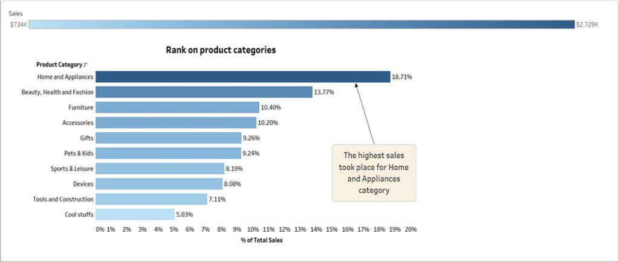

*Graph 1. Product categories and their proportional sales*

Managing the seasonality of demand becomes easier with the next visualization in this dashboard which examines sales by season. Graph 2 helps us to gauge the peaks and the dips of sales based on seasonality. It is apparent that our sales continue to grow in the first half of the year but there’s a significant dip in Fall in the month of September. It is therefore imperative that we focus on these plunges and adopt aggressive marketing techniques such as flash sales or reward programs to boost sales.

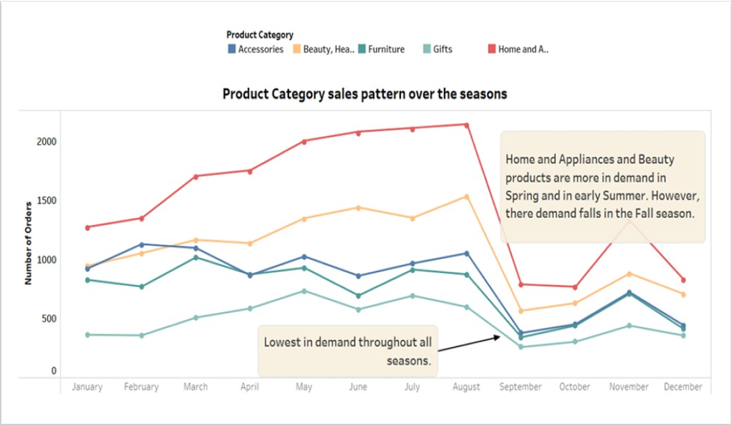

*Graph 2. Sales by season*

Understanding customer buying trends can help Olist in devising personalized digital marketing strategies targeting customers when they need to order (day and time). Additionally, the operations team can also benefit from the dashboard by planning warehouse space and inventory management throughout the week. From Graph 3, we can see that customers buy the most on weekdays (Mon-Fri) and they slow down on the weekends. Offering free delivery will increase the number of customers on weekends without affecting profit margins. Also from graph 4, we can see that customers place the highest number of orders between 12 pm to 4 pm during the day. However, to draw more customers during evening hours, we can implement seasonal pop-ups to Olist site that will help match the holiday or season, drive shopper engagement, and procure more orders.

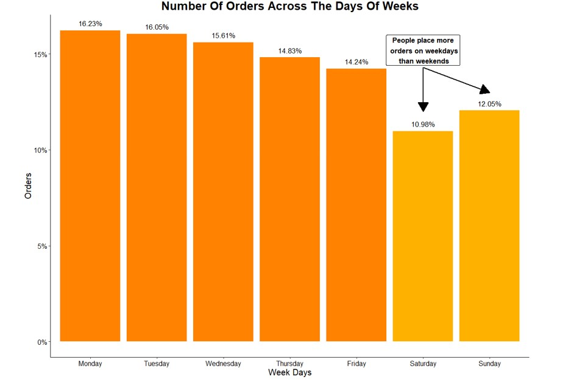

*Graph 3. Customer buying behavior across the days of weeks*

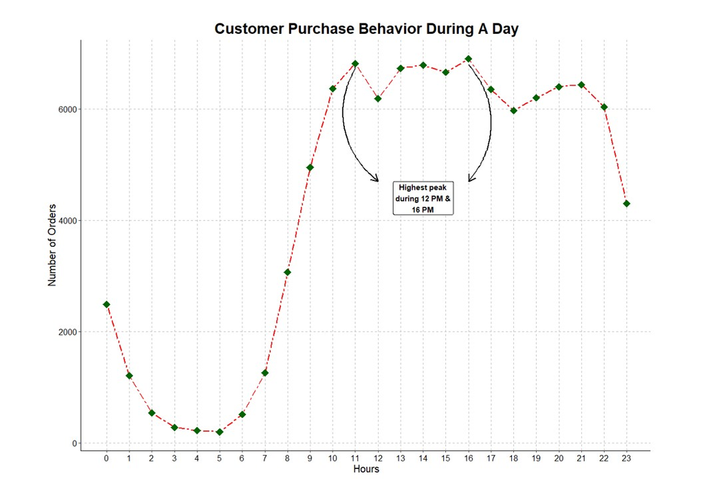

*Graph 4. Customer purchase behavior during a day*

Another important tool on this dashboard is the data about the payment types used by Olist customers. Knowledge of this data is pertinent because when considering the customer experience, it’s important for merchants to offer a variety of payments. The use of **Boleto** as a platform is growing exponentially in recent times with an increasing number of users adopting it . Although only 19% of our users at Olist currently pay with Boleto, it is an opportunity for us to acquire Boleto users as new customers by partnering with Boleto and offering promotional discounts and attractive payment gateway commissions.

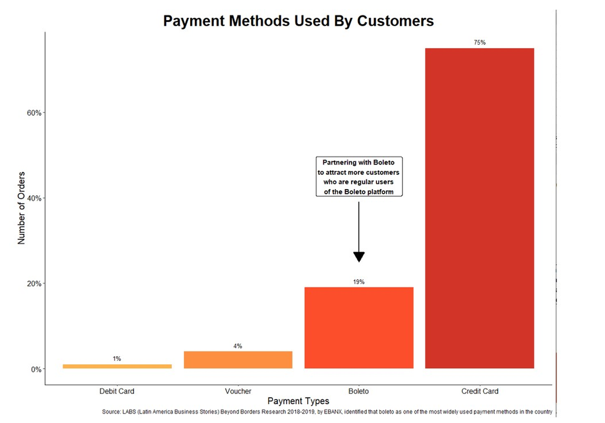

*Graph 5. Payment type used by the customer*

Next on our dashboard is the sentiment analysis of our customers across various categories. Although almost 75% of customers rated **‘satisfied’** and **‘very satisfied’** amongst all the categories, we also have around 9-14% of the customers who rated the products as **‘very unsatisfactory’** and this is concerning. These insights are useful for the customer service teams as well as the category managers to delve deeper into their respective categories. For instance, the category manager for furniture needs to pull their socks up since it has the highest **‘very unsatisfied’** rating (14.29%). Hence, for improving the customer experience, Olist retail teams should onboard vendors with a good track record of providing high quality furniture inventory. We should reach out to sellers to post candid videos of furniture to highlight product quality along with proper product description. Additionally, we should also focus on the packaging quality to prevent heavy duty products from getting damaged during transportation.

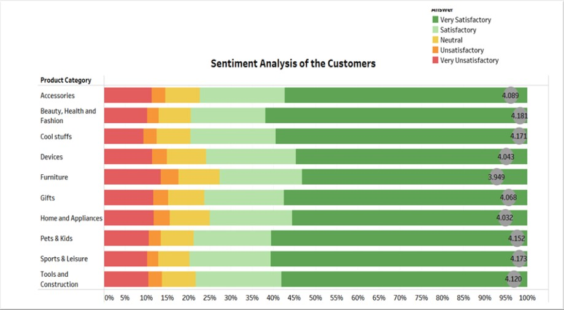

*Graph 6. Customer review score*

## 2. Operations and Logistics Dashboard

The aim of the Operations and Logistics dashboard is to highlight valuable data in order to improve efficiency, productivity and reduce delivery time and shipping cost.

[figure not shown]

*Graph 7. Map for Top sales by state and seller-customer density*

In comparison with the sales map, the seller/customer density map shows that although seller/customer density is higher in the central and eastern part, the delivery time and the shipping cost is still very high as compared to the southern part. Hence, to improve productivity and reduce delivery time and shipping costs we suggest having fulfillment centers in Mato Grosso (MT). As the seller/customer density is 57% in MT and it is located in the central part of the country it will be convenient for the logistics to reach out to more customers in MT and as well as in the neighboring states where the average shipping cost is higher and delivery time is more. We also advise reaching out to the sellers in the neighboring states and ensuring they have enough stock for Mato Grosso fulfillment center. This will help Olist to grow their business and at the same time create a better customer experience in terms of delivery time and shipping cost. It will also help sellers to save their money they are spending on transportation.

[figure not shown]

Shipping costs in an eCommerce business not only affect the company’s revenue but also have a direct impact on the customer’s shopping experience. It is often the final determinant of whether the customer would buy the product. Graph 9 demonstrates the average shipping cost based on categories. The top 5 categories with the highest average shipping cost are Security, Furniture, Industry commerce, Tools and construction, Music and audio. Out of these top 5 product categories most of them are heavy, big in size, have the highest average shipping cost and will require a substantial amount of truck floor and wall space. Hence, we would recommend tying up with Third party logistics solutions providers to deliver these products which will help to reduce shipping costs by cutting extra services such as shipping insurance and freight savings etc.

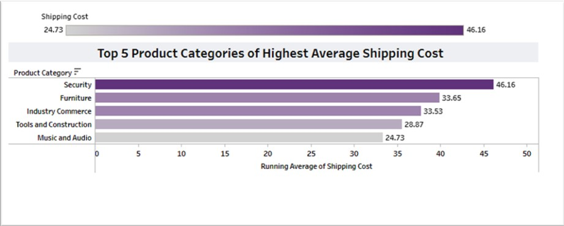

*Graph 9. Average shipping cost for top product categories*

Delivery analytics improves the order processing capabilities of our organization, exposes any ongoing problems in the supply chain, and allows the concerned teams to fix the issues faster. Graph 10 illustrates the delivery performance of the orders in general. Most of the orders are delivered earlier than the expected date. However, there are over 4000 orders that are delayed by less than a week and more than 3000 orders that were delayed for more than a week resulting in extremely poor customer experience. Hence , having a fulfillment center as suggested earlier will help to reach out to more customers in less time and will result in greater customer satisfaction.

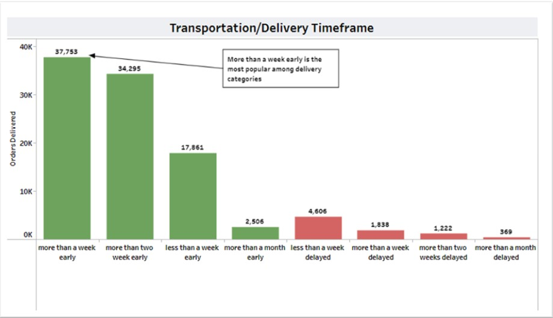

*Graph 10. Delivery timeframe*

The above dashboards and the data insights provided in them simplify and highlight key metrics that various Olist teams can easily comprehend and use to streamline procedures. The given data would help cross-functional teams at Olist to measure and evaluate the effectiveness of solutions, functions, and processes in the business as well as devise innovative strategies to combat areas that need improvement. In addition, the teams can customize data within the dashboards and concenter while analyzing trends that are important to the business and choose to zoom into relevant insights or metrics.

**Limitations:**

- Our dataset is limited to data from 2016 to 2018. If we would have more recent data, then we would have analyzed the trend much more efficiently for both our research categories, especially after COVID.
- We don’t have Olist fulfillment center/warehouse locations data which would have helped us to make better judgments in suggesting in which state we should have our new fulfillment center.

**Links for dashboards:**

[Operations and Logistics dashboard | Tableau Public](https://public.tableau.com/app/profile/sugandha.baruah/viz/OperationsandLogisticsdashboard/OperationsandLogistics?publish=yes)

[Customer buying behavior dashboard | Tableau Public](https://public.tableau.com/app/profile/sugandha.baruah/viz/Customerbuyingbehaviordashboard/CustomerBehavior?publish=yes)

**References:**

1. Dataset: acquired from kaggle.com <*https://www.kaggle.com/datasets/olistbr/brazilian-ecommerce?datasetId=55151&sortBy=voteCount*>
2. LABS (Latin America Business Stories) Beyond Borders Research 2018-2019, by EBANX, identified that Boleto as one of the most widely used payment methods in the country” <*https://labsnews.com/en/articles/ecommerce/why-boleto-is-more-than-ever-a-rising-payment-method-in-brazil/*>
3. SKUBANA- “Shipping Smart - The Elements You Need to Factor in Your Shipping Costs”: April 14, 2020 <*https://www.skubana.com/blog/shipping-costs*>
4. JUSTUNO- “10 Ways to Increase Online Sales During Slow Shopping Months- E-Commerce, Conversion Optimization, Promotion Strategy”: July 11, 2016 <*https://www.justuno.com/blog/10-ways-to-drive-e-commerce-sales-during-slow-online-shopping-months/*>